# Analyzing nicotine concentrations on vape/mice exposed towels

Erik Parker for the Biostatistics Consulting Center (BCC)

03 September 2025

# Descriptive tables

## Nicotine concentration by group

```r
towel.data %>%
  select(group, nicotine_mass_ng_sample) %>% # select variables
  tbl_summary(by = group, # make the table, stratified by group
              type = list(nicotine_mass_ng_sample ~ "continuous2"), # tell it to make multiple rows of stats output for continuous variables
              statistic = list(all_continuous() ~ c("{mean} ({sd})", "{median} ({p25}, {p75})", "{min}, {max}")), # select and format which stats I want
              missing_text = "Missing")  %>% # missing observations are marked as "missing"
  bold_labels() %>%
  add_overall(last = T) %>% # add overall column, put it last
  add_p(pvalue_fun = label_style_pvalue(digits = 3)) # add p-value for bivariate tests
```

| **Characteristic** | **Double negative control** N = 3 | **Exposed** N = 9 | **Negative control** N = 13 | **Positive control** N = 3 | **Overall** N = 28 | **p-value**<sup>1</sup> |
| --- | --- | --- | --- | --- | --- | --- |
| nicotine_mass_ng_sample |  |  |  |  |  | <0.001 |
| Mean (SD) | 4 (6) | 37,188 (14,814) | 13 (4) | 62,032 (29,167) | 18,606 (25,643) |  |
| Median (Q1, Q3) | 0 (0, 11) | 38,929 (23,016, 46,235) | 14 (13, 15) | 60,678 (33,565, 91,853) | 16 (13, 36,247) |  |
| Min, Max | 0, 11 | 18,252, 58,725 | 4, 18 | 33,565, 91,853 | 0, 91,853 |  |

<sup>1</sup> Kruskal-Wallis rank sum test

## Nicotine concentration by batch

However, we don’t see significant differences by batch, so it is probably not necessary to account for batch in our models.

```r
towel.data %>%
  select(batch, nicotine_mass_ng_sample) %>% # select variables
  tbl_summary(by = batch, # make the table, stratified by group
              type = list(nicotine_mass_ng_sample ~ "continuous2"), # tell it to make multiple rows of stats output for continuous variables
              statistic = list(all_continuous() ~ c("{mean} ({sd})", "{median} ({p25}, {p75})", "{min}, {max}")), # select and format which stats I want
              missing_text = "Missing")  %>% # missing observations are marked as "missing"
  bold_labels() %>%
  add_overall(last = T) %>% # add overall column, put it last
  add_p(pvalue_fun = label_style_pvalue(digits = 3)) # add p-value for bivariate tests
```

| **Characteristic** | **1** N = 10 | **2** N = 10 | **3** N = 8 | **Overall** N = 28 | **p-value**<sup>1</sup> |
| --- | --- | --- | --- | --- | --- |
| nicotine_mass_ng_sample |  |  |  |  | 0.754 |
| Mean (SD) | 19,373 (28,924) | 17,030 (23,139) | 19,616 (27,691) | 18,606 (25,643) |  |
| Median (Q1, Q3) | 9,135 (15, 23,016) | 14 (13, 33,565) | 14 (11, 48,097) | 16 (13, 36,247) |  |
| Min, Max | 0, 91,853 | 0, 58,725 | 4, 60,678 | 0, 91,853 |  |

<sup>1</sup> Kruskal-Wallis rank sum test

# Exploratory plots

Below we have a few exploratory plots for concentrations of nicotine against the treatment group and batch variables.

## Nicotine concentration by randomization group

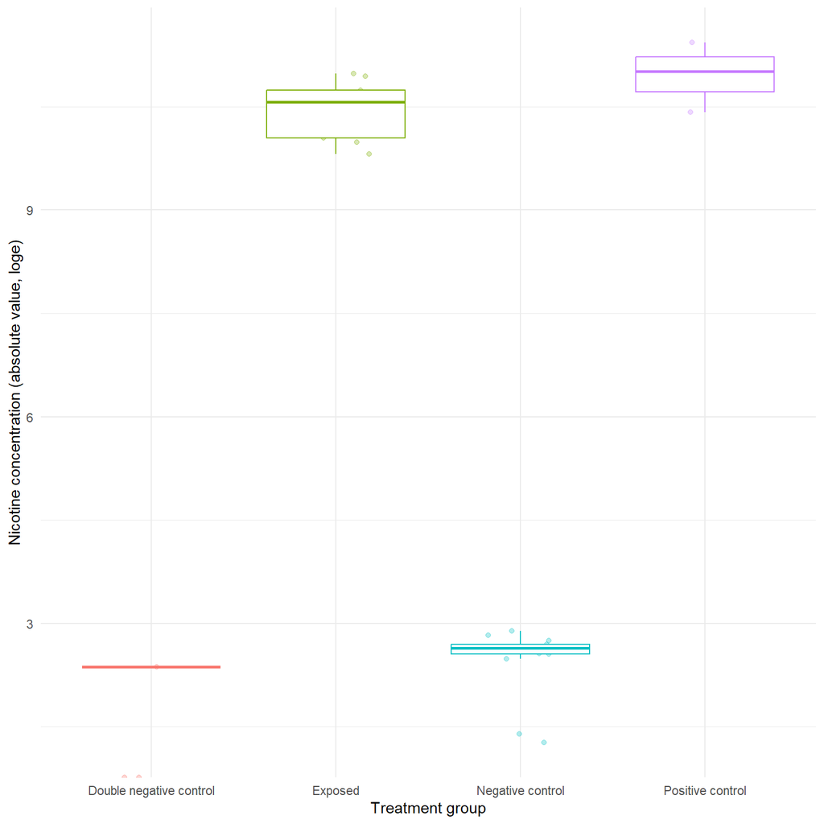

```r
towel.data %>%
  ggplot(aes(x = group, y = log(abs(nicotine_mass_ng_sample)), colour = group)) + # make plot of metal concentration by group
    geom_jitter(alpha = 0.3, width = 0.2, size = 1.5) + # plot points
    geom_boxplot(outliers = F) + # make boxplot
    theme_minimal() + # use minimal theme
    labs(x = "Treatment group", y = "Nicotine concentration (absolute value, loge)", color = "") + # set the labels
    theme(legend.position="none") # remove the legend
```

## Nicotine concentration by batch

Here we see no real difference in Nicotine concentration across the 3 batches.

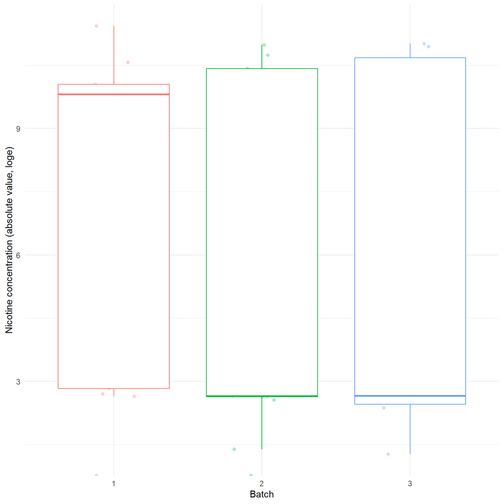

```r
towel.data %>%
  ggplot(aes(x = batch, y = log(abs(nicotine_mass_ng_sample)), colour = batch)) + # make plot of metal concentration by batch
    geom_jitter(alpha = 0.3, width = 0.2, size = 1.5) + # plot points
    geom_boxplot(outliers = F) + # make boxplot
    theme_minimal() + # use minimal theme
    labs(x = "Batch", y = "Nicotine concentration (absolute value, loge)", color = "") + # set the labels
    theme(legend.position="none") # remove the legend
```

# Linear model analysis

From these analyses, we see that when we account for towel weight, we still see that there are significant differences between nicotine concentration in the four groups (p < 0.001). And from the pairwise comparisons, we see that the double negative control group shows significantly lower nicotine levels as compared to exposed (p = 0.0034) and positive control (p < 0.001) conditions. We also see significant differences between the exposed and negative control (p < 0.001) and between the negative control and the positive control (p < 0.001).

## Estimates table with betas and p-values

Here we have a model summary table with estimated betas for the group variable, type 3 p-values, and model statistics.

```r
model <- lm(nicotine_mass_ng_sample ~ group + towel_weight_g, data = towel.data)


model %>%
  tbl_regression(pvalue_fun = ~ style_pvalue(.x, digits = 3))%>%
  add_global_p() %>% # add global p-value, using the anova function
  bold_p(t = 0.1) %>% # add and bold type 3 anova, global, p-values above 0.1.
  italicize_levels() %>%
  add_glance_table(include = everything())
```

| **Characteristic** | **Beta** | **95% CI** | **p-value** |
| --- | --- | --- | --- |
| group |  |  | <0.001 |
| Double negative control | — | — |  |
| Exposed | 30,067 | 14,258, 45,875 |  |
| Negative control | -5,776 | -20,696, 9,143 |  |
| Positive control | 55,832 | 37,072, 74,593 |  |
| towel_weight_g | 28,597 | 6,269, 50,925 | 0.014 |
| R² | 0.851 |  |  |
| Adjusted R² | 0.825 |  |  |
| Sigma | 10,731 |  |  |
| Statistic | 32.8 |  |  |
| p-value | <0.001 |  |  |
| df | 4 |  |  |
| Log-likelihood | -297 |  |  |
| AIC | 606 |  |  |
| BIC | 614 |  |  |
| Deviance | 2,648,783,479 |  |  |
| Residual df | 23 |  |  |
| No. Obs. | 28 |  |  |

Abbreviation: CI = Confidence Interval

## Pairwise estimated marginal means

Then we have estimated means for each treatment group, and pairwise comparisons to see if there are any significant differences between particular groups.

```r
emm <- emmeans(model, pairwise ~ group)

emm
```

```
## $emmeans
##  group                   emmean   SE df lower.CL upper.CL
##  Double negative control   5641 6550 23    -7911    19193
##  Exposed                  35708 3620 23    28218    43197
##  Negative control          -135 2980 23    -6293     6023
##  Positive control         61473 6200 23    48649    74298
##
## Confidence level used: 0.95
##
## $contrasts
##  contrast                                   estimate   SE df t.ratio p.value
##  Double negative control - Exposed            -30067 7640 23  -3.934  0.0034
##  Double negative control - Negative control     5776 7210 23   0.801  0.8533
##  Double negative control - Positive control   -55832 9070 23  -6.156  <.0001
##  Exposed - Negative control                    35843 4680 23   7.658  <.0001
##  Exposed - Positive control                   -25766 7160 23  -3.597  0.0077
##  Negative control - Positive control          -61608 6880 23  -8.961  <.0001
##
## P value adjustment: tukey method for comparing a family of 4 estimates
```

## Plot of predicted probabilities

Finally, here we have a plot of the predicted values for each group. These are helpful to illustrate the significance (or not) of interactions in these models.

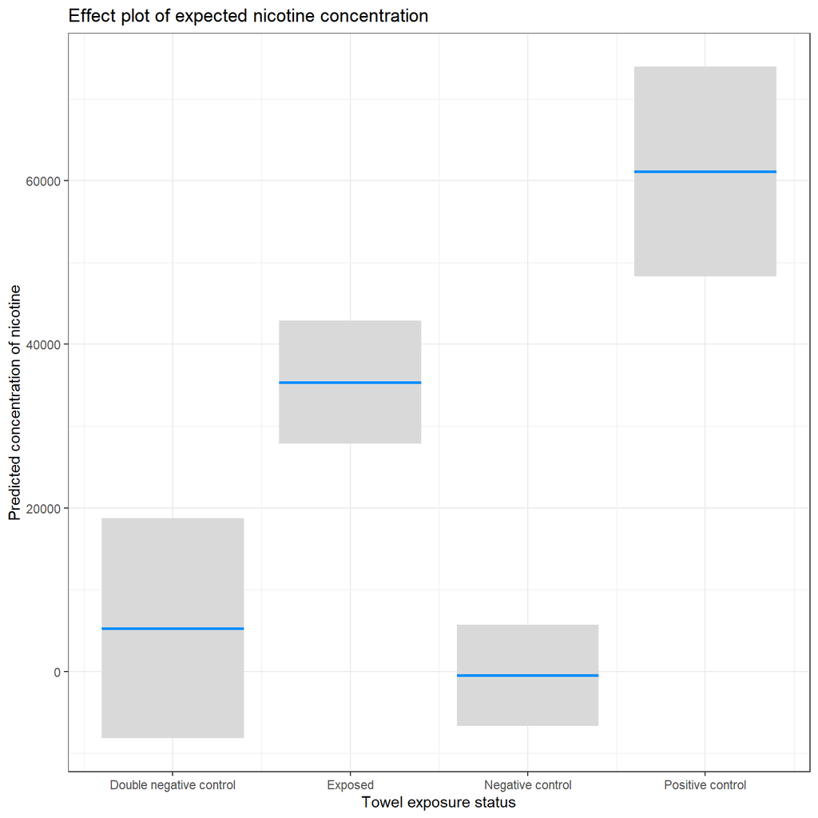

```r
visreg::visreg(model, xvar = "group", scale = "response", gg = TRUE, overlay = TRUE, partial = FALSE, rug = FALSE) +
          theme_bw() +
          labs(title = paste("Effect plot of expected nicotine concentration"), y = paste("Predicted concentration of nicotine"), x = "Towel exposure status")
```